# Exploring Red Wine Quality by Jin Lim

> The Red Wine dataset concerns the red variant of the Portuguese “Vinho Verde” wine. It contains 1599 observations and 11 input variables, as well as an output variable called “quality” on a scale of 0 (very bad)-10 (very excellent). Our task is to determine which variables have statistically significant impacts on the quality of wine.

> This dataset is provided by Udacity and is named “wineQualityReds.csv”

# Structure and Summary of Dataframe

```
##  [1] "fixed.acidity"        "volatile.acidity"     "citric.acid"
##  [4] "residual.sugar"       "chlorides"            "free.sulfur.dioxide"
##  [7] "total.sulfur.dioxide" "density"              "pH"
## [10] "sulphates"            "alcohol"              "quality"
```

```
##  fixed.acidity   volatile.acidity  citric.acid    residual.sugar
##  Min.   : 4.60   Min.   :0.1200   Min.   :0.000   Min.   : 0.900
##  1st Qu.: 7.10   1st Qu.:0.3900   1st Qu.:0.090   1st Qu.: 1.900
##  Median : 7.90   Median :0.5200   Median :0.260   Median : 2.200
##  Mean   : 8.32   Mean   :0.5278   Mean   :0.271   Mean   : 2.539
##  3rd Qu.: 9.20   3rd Qu.:0.6400   3rd Qu.:0.420   3rd Qu.: 2.600
##  Max.   :15.90   Max.   :1.5800   Max.   :1.000   Max.   :15.500
##    chlorides       free.sulfur.dioxide total.sulfur.dioxide
##  Min.   :0.01200   Min.   : 1.00       Min.   :  6.00
##  1st Qu.:0.07000   1st Qu.: 7.00       1st Qu.: 22.00
##  Median :0.07900   Median :14.00       Median : 38.00
##  Mean   :0.08747   Mean   :15.87       Mean   : 46.47
##  3rd Qu.:0.09000   3rd Qu.:21.00       3rd Qu.: 62.00
##  Max.   :0.61100   Max.   :72.00       Max.   :289.00
##     density             pH          sulphates         alcohol
##  Min.   :0.9901   Min.   :2.740   Min.   :0.3300   Min.   : 8.40
##  1st Qu.:0.9956   1st Qu.:3.210   1st Qu.:0.5500   1st Qu.: 9.50
##  Median :0.9968   Median :3.310   Median :0.6200   Median :10.20
##  Mean   :0.9967   Mean   :3.311   Mean   :0.6581   Mean   :10.42
##  3rd Qu.:0.9978   3rd Qu.:3.400   3rd Qu.:0.7300   3rd Qu.:11.10
##  Max.   :1.0037   Max.   :4.010   Max.   :2.0000   Max.   :14.90
##     quality
##  Min.   :3.000
##  1st Qu.:5.000
##  Median :6.000
##  Mean   :5.636
##  3rd Qu.:6.000
##  Max.   :8.000
```

```
## 'data.frame':    1599 obs. of  12 variables:
##  $ fixed.acidity       : num  7.4 7.8 7.8 11.2 7.4 7.4 7.9 7.3 7.8 7.5 ...
##  $ volatile.acidity    : num  0.7 0.88 0.76 0.28 0.7 0.66 0.6 0.65 0.58 0.5 ...
##  $ citric.acid         : num  0 0 0.04 0.56 0 0 0.06 0 0.02 0.36 ...
##  $ residual.sugar      : num  1.9 2.6 2.3 1.9 1.9 1.8 1.6 1.2 2 6.1 ...
##  $ chlorides           : num  0.076 0.098 0.092 0.075 0.076 0.075 0.069 0.065 0.073 0.071 ...
##  $ free.sulfur.dioxide : num  11 25 15 17 11 13 15 15 9 17 ...
##  $ total.sulfur.dioxide: num  34 67 54 60 34 40 59 21 18 102 ...
##  $ density             : num  0.998 0.997 0.997 0.998 0.998 ...
##  $ pH                  : num  3.51 3.2 3.26 3.16 3.51 3.51 3.3 3.39 3.36 3.35 ...
##  $ sulphates           : num  0.56 0.68 0.65 0.58 0.56 0.56 0.46 0.47 0.57 0.8 ...
##  $ alcohol             : num  9.4 9.8 9.8 9.8 9.4 9.4 9.4 10 9.5 10.5 ...
##  $ quality             : int  5 5 5 6 5 5 5 7 7 5 ...
```

# Univariate Plots Section

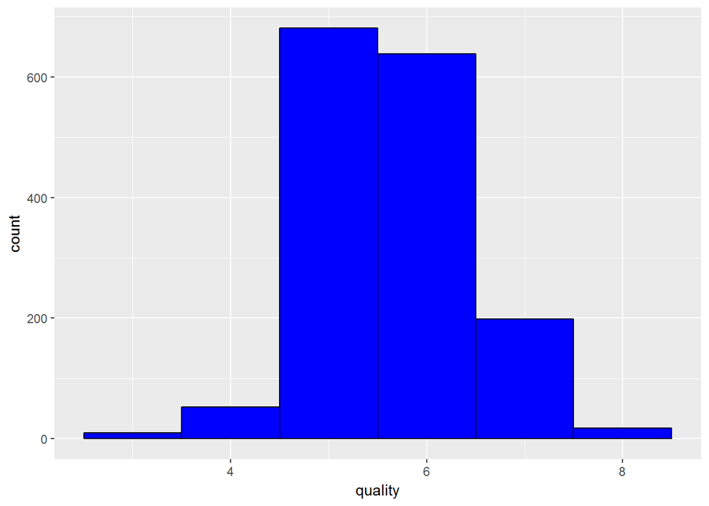

> Let’s look at quality first. From the plot, it appears that most wines are of average (5-6) quality. This is consistent with my expectations as most wine-tasters will usually not grade in extremes as a part of human nature. That is, they will “average” the results in their head and save extreme scores for extreme wines.

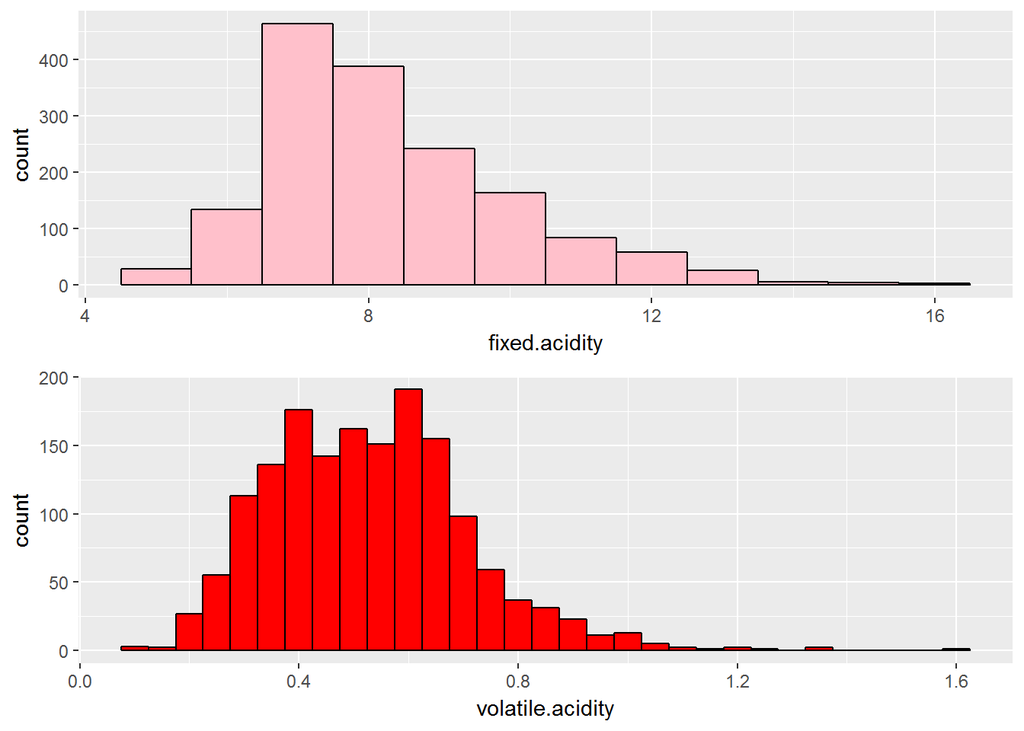

> For acidity, Fixed Acidity seems to be fairly normally-distributed, with a positive or right skew. Volatile Acidity seems to be bimodal, with peaks at 0.4 and 0.6.

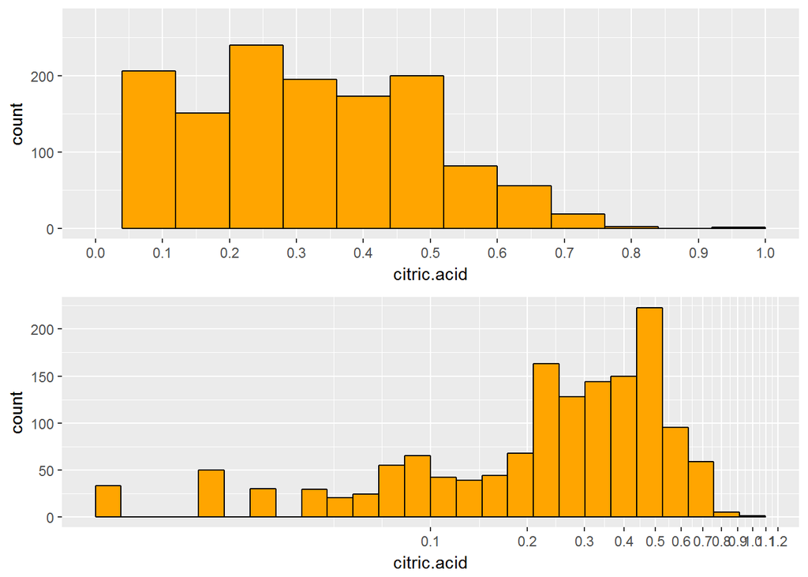

> We scale Citric Acid by log10 due to its long right-tail. Interestingly, the transformation now yields a long left-tail. This could be further explored in the bivariate analysis section.

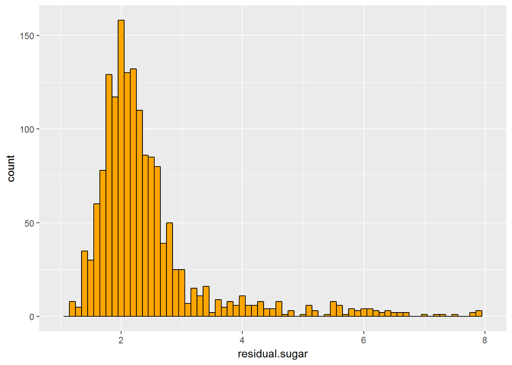

> Residual sugar is very positively skewed and has peaks around 2. It has a lot of outliers on the right-tail.

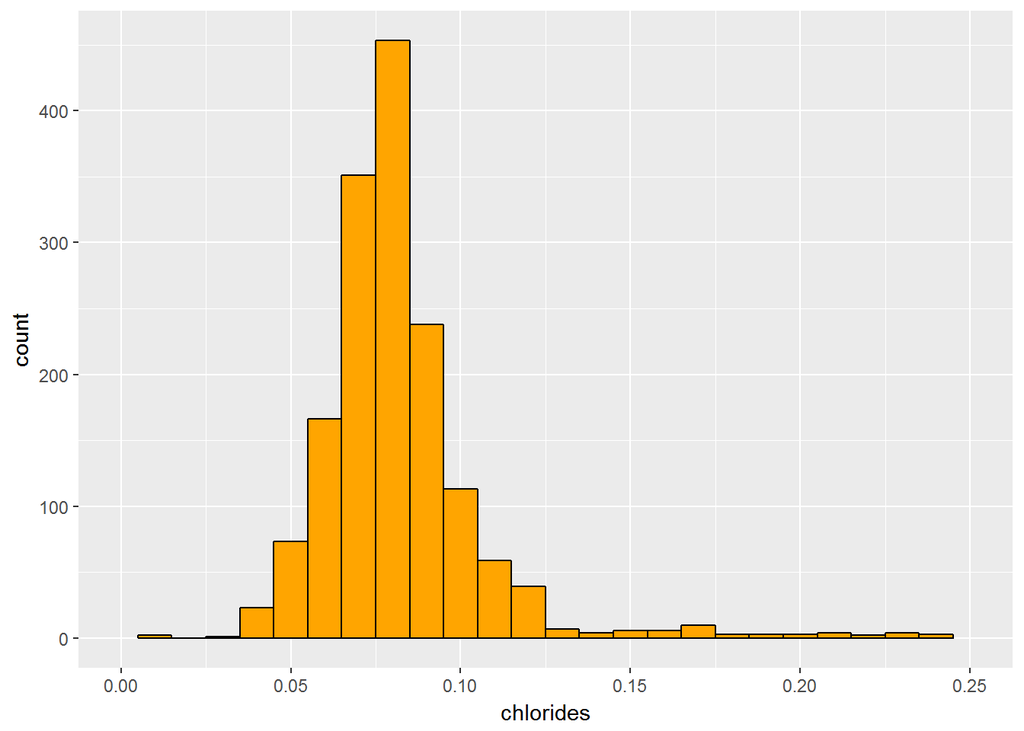

> Chlorides has a similar distribution to Residual Sugar. We see a strong concentration of points around the median and extreme outliers.

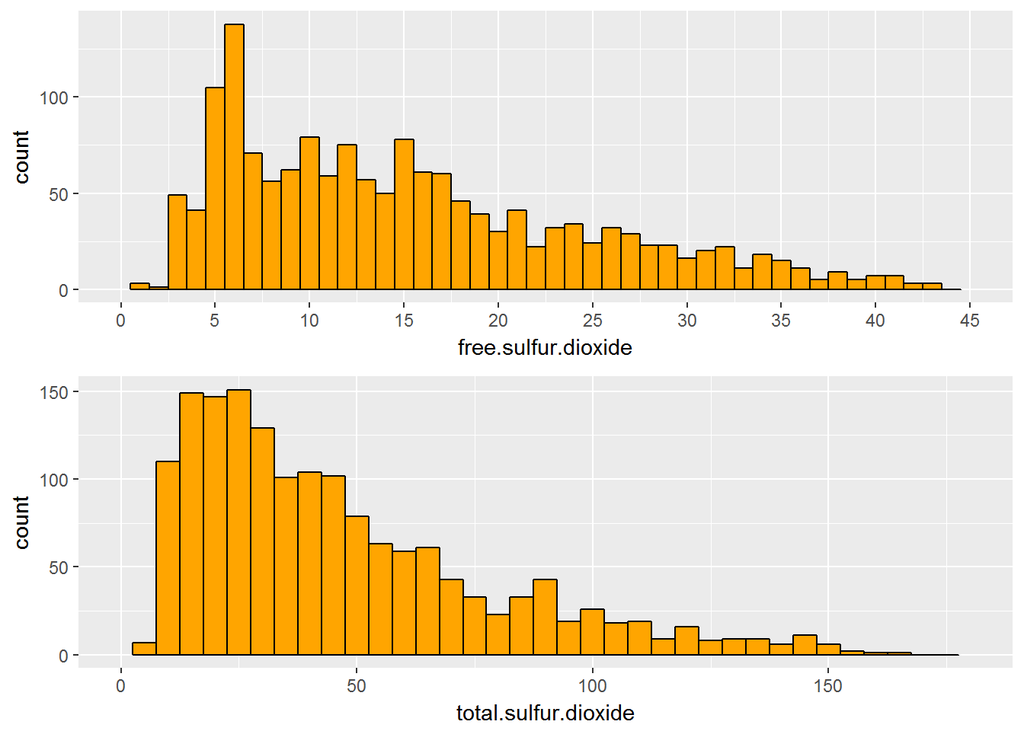

> Relative to the other plots, Free Sulfur Dioxide has a relatively dispersed distribution, but again it has extreme outliers on its right-tail. Total Sulfur Dioxide is less-dispersed, but still follows the same pattern.

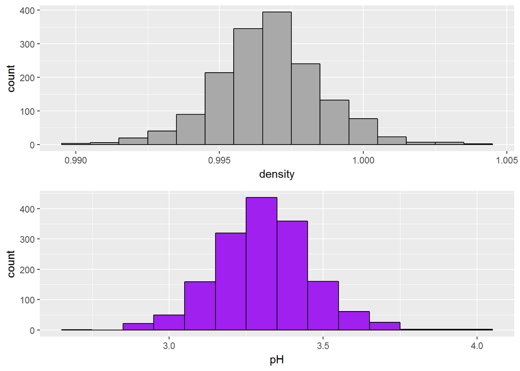

> Both Density and pH are very normally distributed, with concentrations around 0.995-1 and 3.2-3.5 respectively.

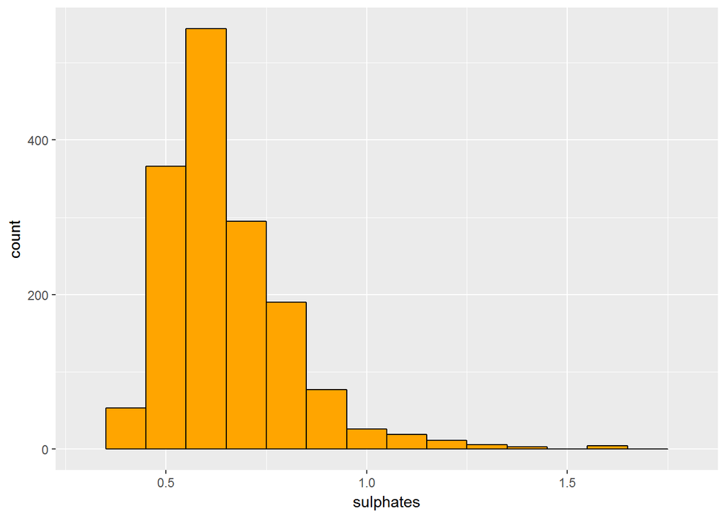

> At first glance, Sulphates is certainly more positively skewed than Density and PH, but I would say the data is still fairly normally-distributed around 0.6. It does not have as many extreme outliers as Chlorides and Free/Total Sulphur Dioxide.

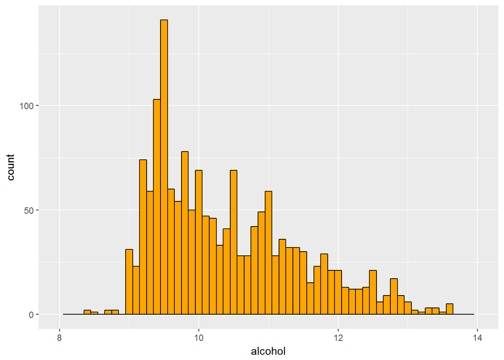

> Alcohol is right-skewed, though not to the extent of Chlorides and Free/Total Sulphur Dioxide.

# Univariate Analysis

### What is the structure of your dataset?

> There are 1599 observations of red wine with twelve features and a (removed) unique identifier. All values are numerical save for quality, which is an integer.

### What is/are the main feature(s) of interest in your dataset?

> The main feature of interest is the output variable “quality”.

### What other features in the dataset do you think will help support your investigation into your feature(s) of interest?

> I would expect alcohol and residual sugar to be fairly positively-correlated with quality. On the other hand, the more extreme the value of pH, the less quality should result.

### Did you create any new variables from existing variables in the dataset?

> No, I did not. I could have perhaps combined fixed/volatile acidity into something like “total acidity”, but I do not think that would affect the quality very much by itself.

### Of the features you investigated, were there any unusual distributions? Did you perform any operations on the data to tidy, adjust, or change the form of the data? If so, why did you do this?

> 1. Citric Acid has a large number of 0 values. I wonder how it can be that some wines do not have this value if most are made of similar grapes. Also, scaling Citric Acid by log10 reverses the tail.
> 2. I was also surprised by the number of extreme outliers in many of the variables. If most of the wines have an average rating, this could mean that for some features, going in an extreme direction does not actually have a signficant impact on taste, if at all.
> 3. For several plots, I did my best to limit the most extreme outliers via scaling limits.

# Bivariate Plots Section

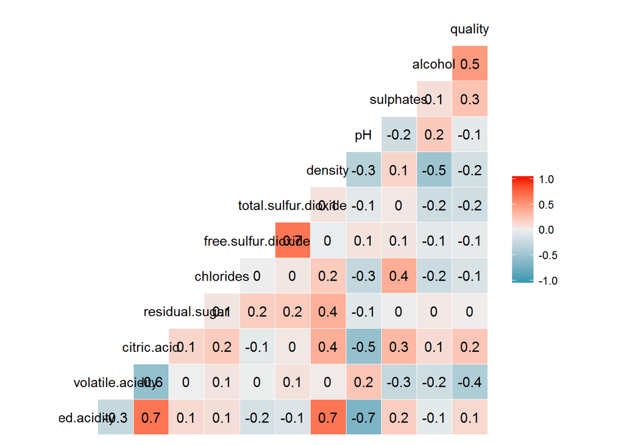

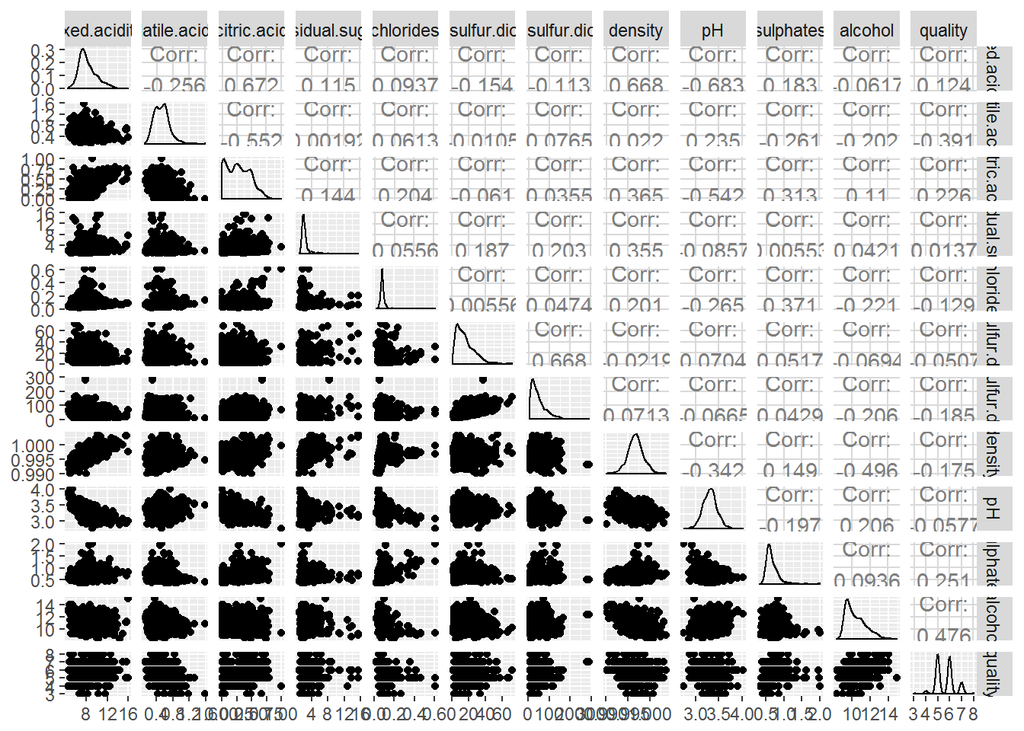

> The top 4 factors correlated with wine quality (>0.2) are: alcohol (0.476), volatile acidity (-0.391), sulphates (0.251), and finally citric acid (0.226).

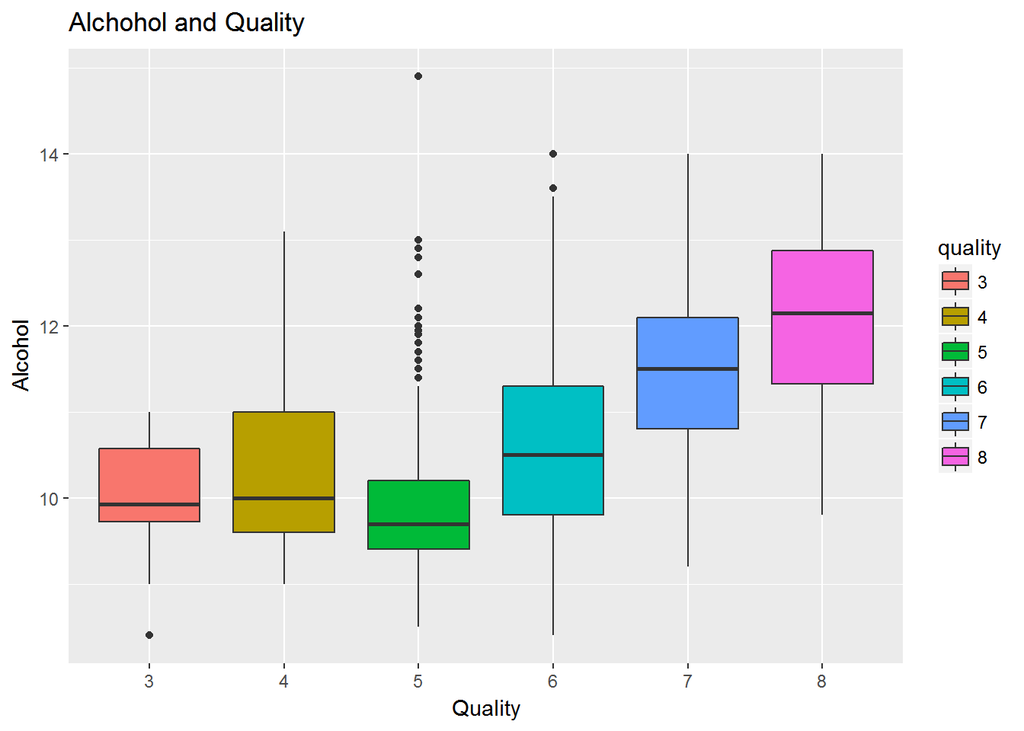

> We converted quality from an integer to a factor in order to plot with box plots. At least one of our assumptions was right: the higher the alcohol content of the wine, the higher the wine is rated.

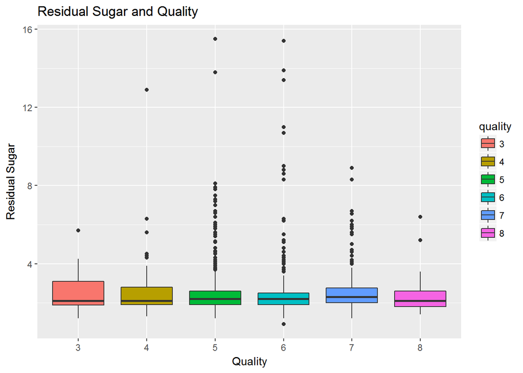

> My assumption about residual sugar was wrong. This is the sugar left after fermentation, so perhaps wine-tasters put more stock by other flavors than sweetness.

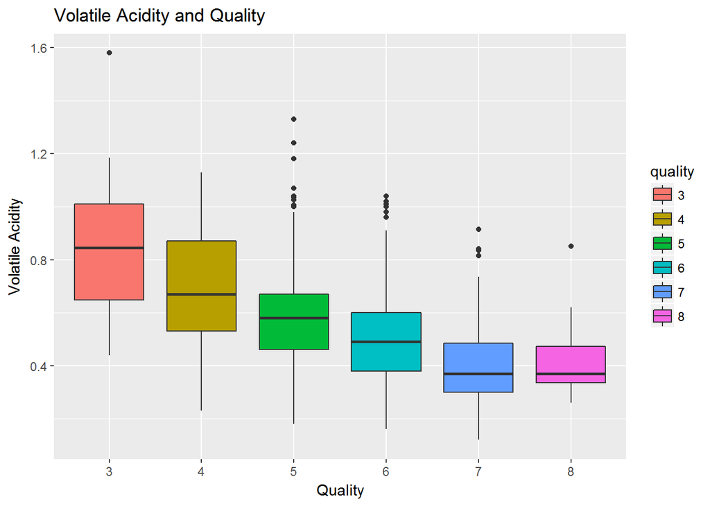

> The more volatile acids there are in a wine, the lower it is rated. Our assumption was based on pH, in that extreme values will have lower scores. Let us examine that next.

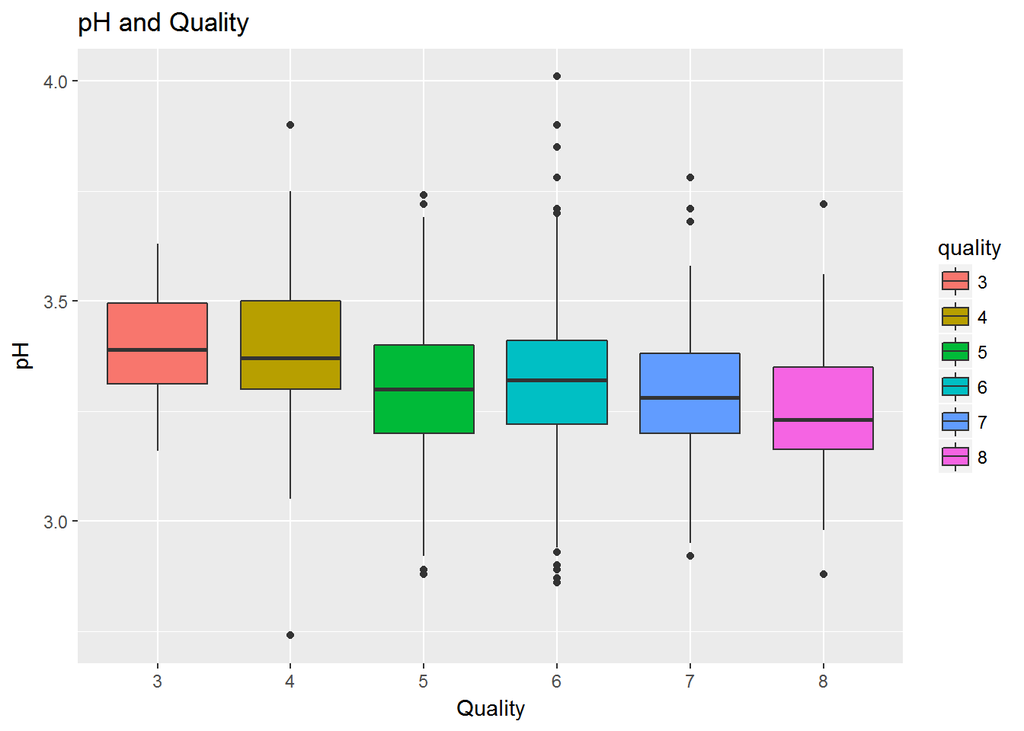

> And oddly enough, it would appear that lesser pH (more acidity) has a correlation with higher quality. So now we have an interesting relationship on our hands: volatile acidity is negatively correlated with quality, but recall citric acid is positively correlated (0.226). It would be worth examining all the acidic factors on a log scale against pH to understand how each factor works in determining acidity.

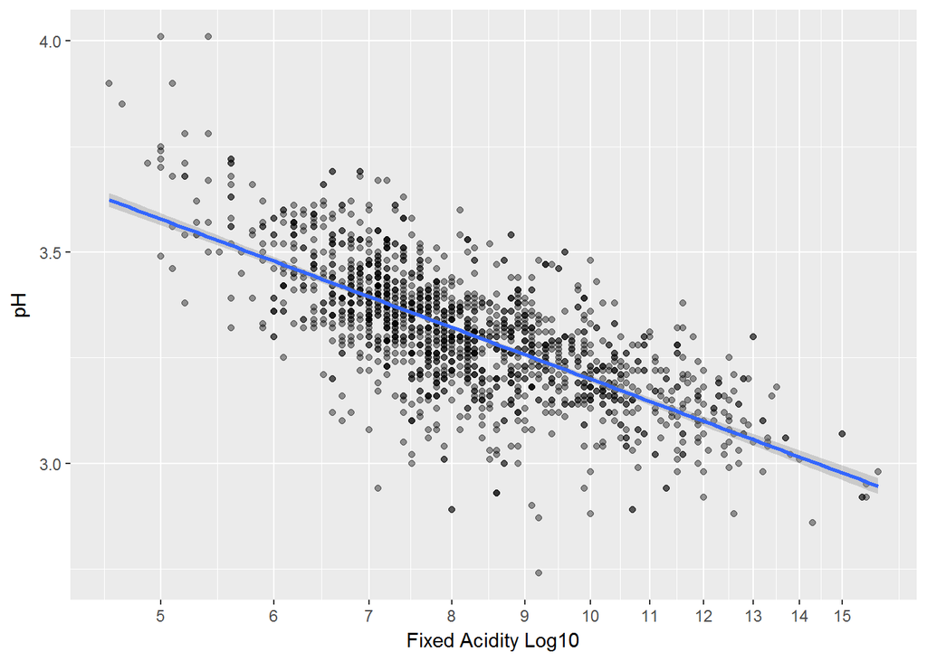

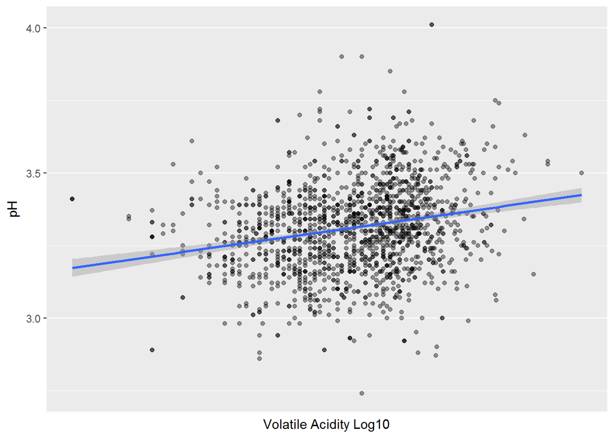

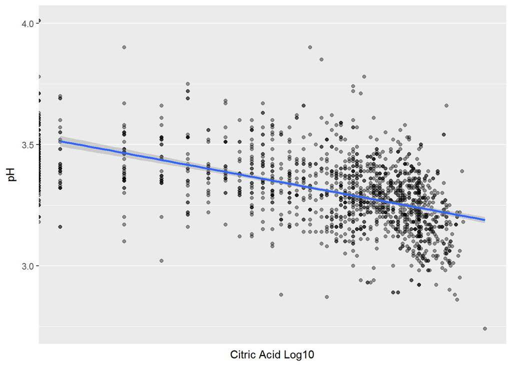

> Fixed and Citric acids correlate with pH as we expected; that is to say, the more acids, the lower the pH value.

> Volatile acidity is odd. The overview suggests it is acetic acid, and that high concentrations impart a vinegar taste. It is, however, positively correlated with pH, and yet we know lower pH means more acidity. This should mean more volatile acidity -> lower pH. Perhaps the more acid is present as “volatile” instead of fixed, the more it evaporates, thus leaving a less acidic pH (assuming wine-tasters wait before drinking).

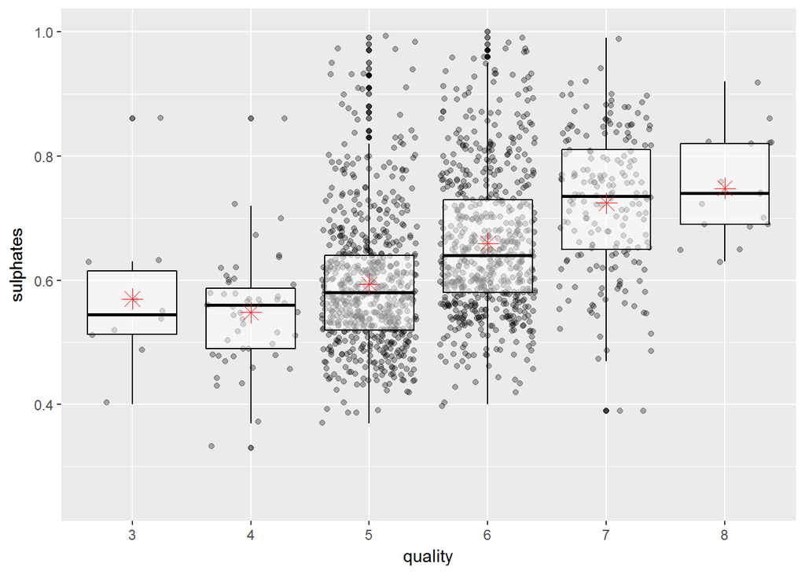

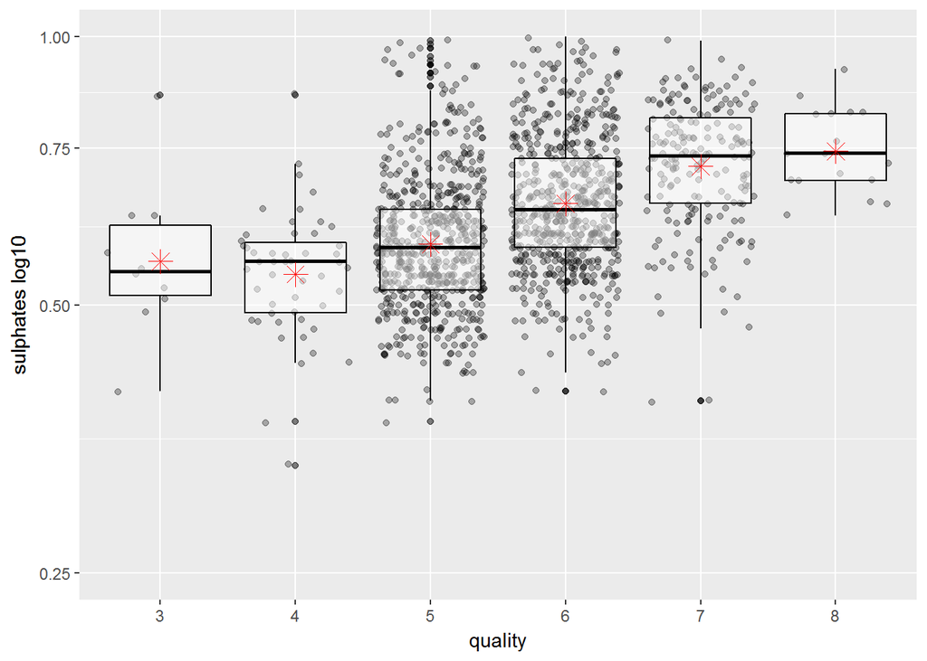

> And here we have the sulphates and sulphateslog10 plots. The more sulphates are present in a wine, the higher its quality. This is consistent as sulphates act as antimicrobials and antioxidants, and thus help preserve a wine. We also decided to scale the plot due to the factor’s original right skew.

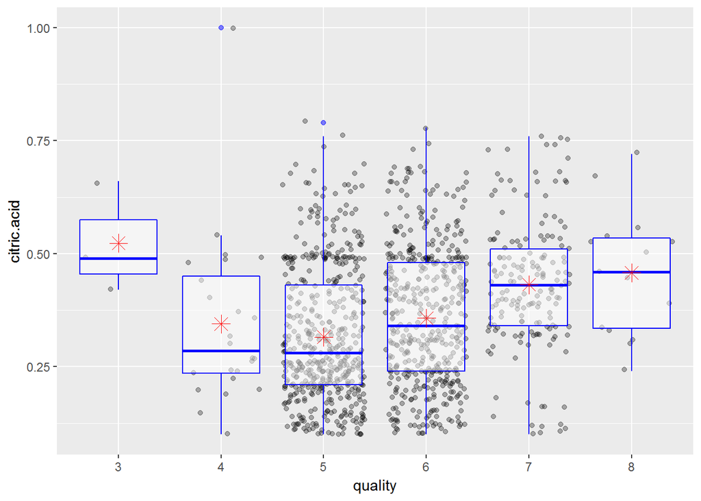

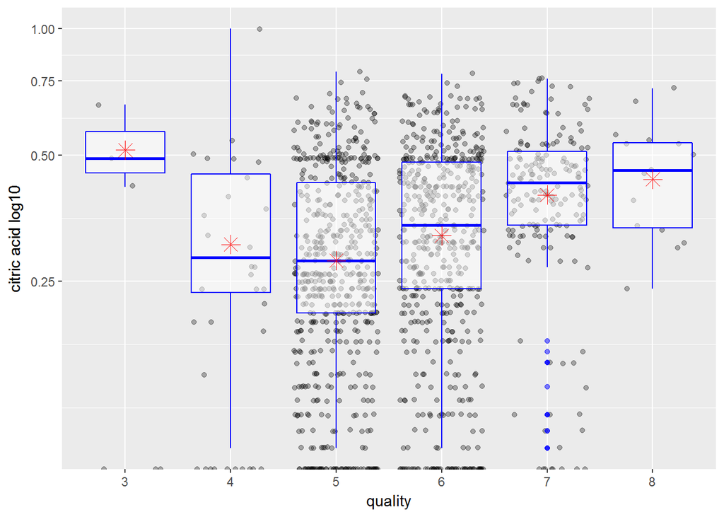

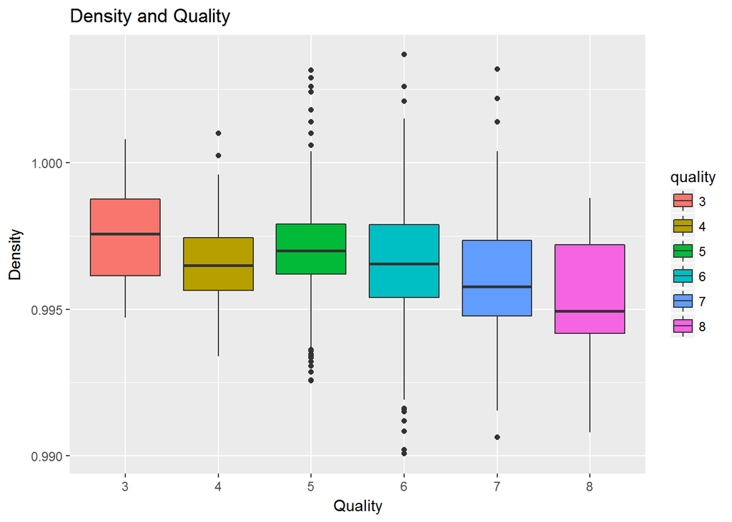

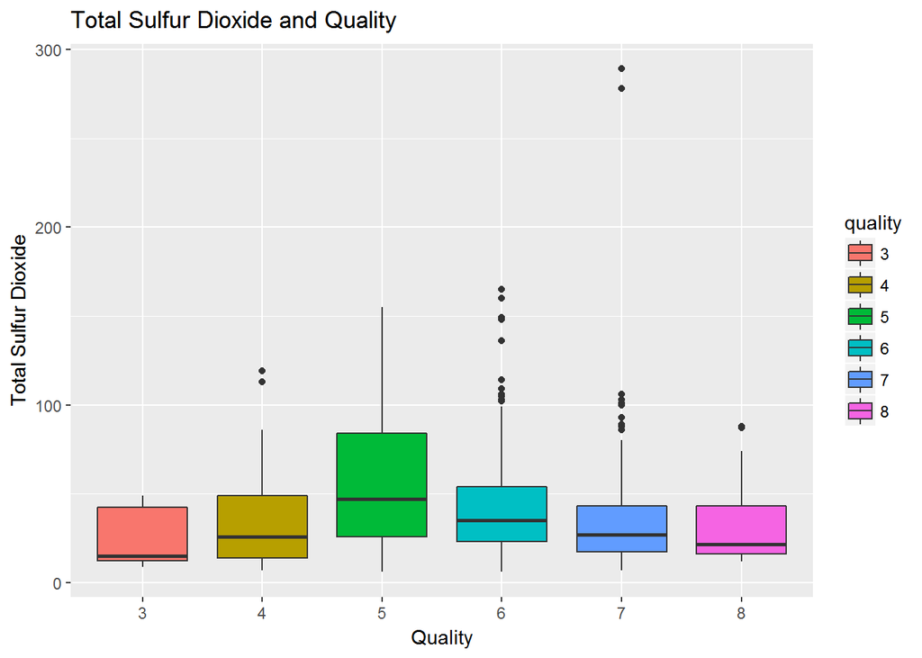

> And just to be thorough, here are the plots for two other factors that had correlations close to 0.2: density (-0.175) and total sulfur dioxide (-0.185).

> Density can be explained, I think. Alcohol is lighter than water, and we already know alcohol was one of our strongest correlative variables; thus, the more alcohol, the less density and the higher the quality. It could also contribute to an “airy” feeling. We’ll test that in the next plot.

> Total sulfur dioxide is also consistent in that more of it can affect the taste of the wine, though the box plot suggests this is an inconsistent correlation at best.

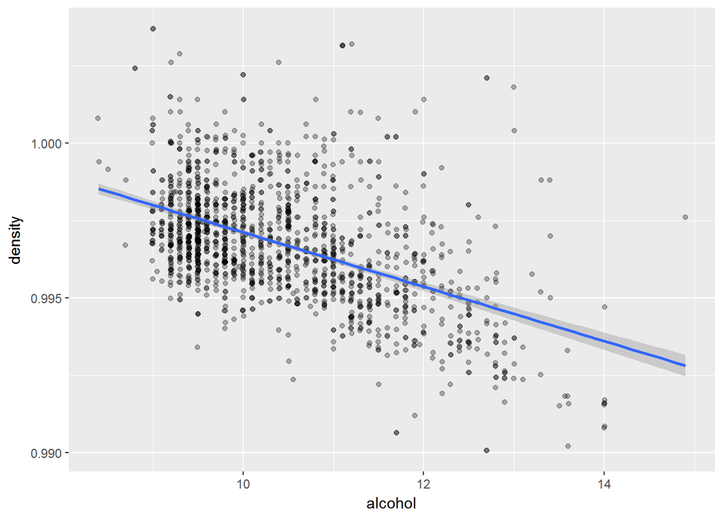

> Here we see that more alcohol results in less density, so density is more a function of that than a predictor of quality.

```
##
## Call:
## lm(formula = as.numeric(quality) ~ alcohol, data = red)
##
## Residuals:
##     Min      1Q  Median      3Q     Max
## -2.8442 -0.4112 -0.1690  0.5166  2.5888
##
## Coefficients:
##             Estimate Std. Error t value Pr(>|t|)
## (Intercept) -0.12503    0.17471  -0.716    0.474
## alcohol      0.36084    0.01668  21.639   <2e-16 ***
## ---
## Signif. codes:  0 '***' 0.001 '**' 0.01 '*' 0.05 '.' 0.1 ' ' 1
##
## Residual standard error: 0.7104 on 1597 degrees of freedom
## Multiple R-squared:  0.2267, Adjusted R-squared:  0.2263
## F-statistic: 468.3 on 1 and 1597 DF,  p-value: < 2.2e-16
```

> A simple linear regression model of alcohol returns an R-squared of about 0.23. Despite its low value, I am quite pleased with the result. I did not expect one factor to be able to fully explain quality when there are so many other variables at play. Alcohol will be an important piece of the puzzle.

# Bivariate Analysis

### Talk about some of the relationships you observed in this part of the investigation. How did the feature(s) of interest vary with other features in the dataset?

> 1. Alcohol (positive), volatile acidity (negative), sulphates (positive) and citric acid (positive) are the strongest predictors of wine quality.
> 2. Surprisingly, residual sugar had almost no explanatory effect on wine quality.
> 3. Despite volatile acidity’s negative effect on quality, as a general rule, the more acidic the wine, the better it tastes.

### Did you observe any interesting relationships between the other features (not the main feature(s) of interest)?

> 1. The most surprising relationship was volatile acidity’s positive correlation with pH. We’d assume more acids result in more acidity (i.e, lower pH), especially when fixed acidity and citric acid both exihibit the expected trend on pH.
> 2. Also of note is fixed acidity’s strong (0.668) positive correlation with density. I am unsure how this relationship works.

### What was the strongest relationship you found?

> The strongest relationship on quality was alcohol. The strongest relationships overall were fixed acidity -> pH (negative), citric acid (positive) at around 0.7.

# Multivariate Plots Section

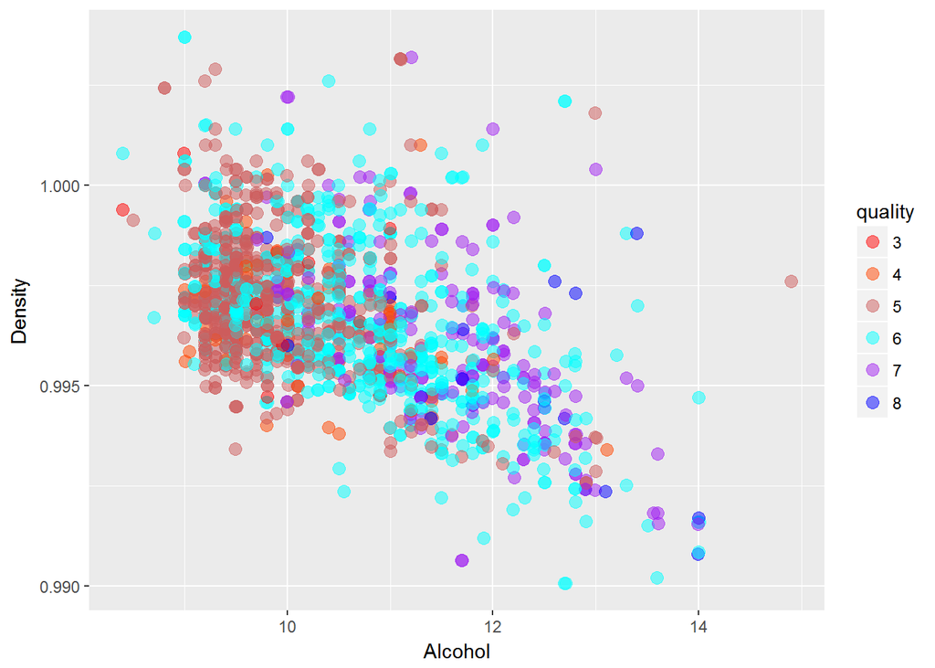

> As can be seen from the plot, higher quality wines in blue colors tend to have high alcohol content and low densities. Holding alcohol constant, density has no real explanatory effect on wine quality, confirming our prior guess that it was alcohol contributing to lower density and its slight positive correlation with quality.

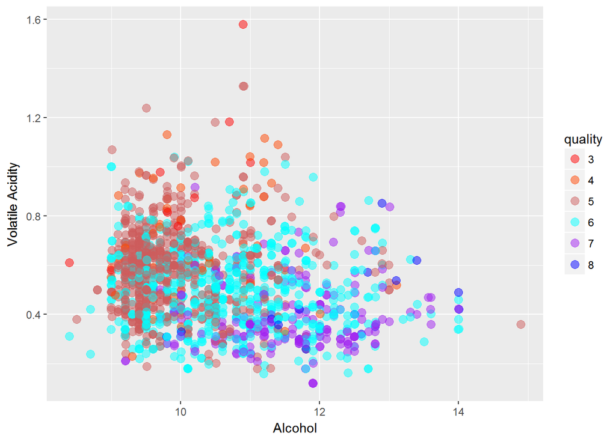

> The highest quality wines tend to have low volatile acidity and high alcohol content.

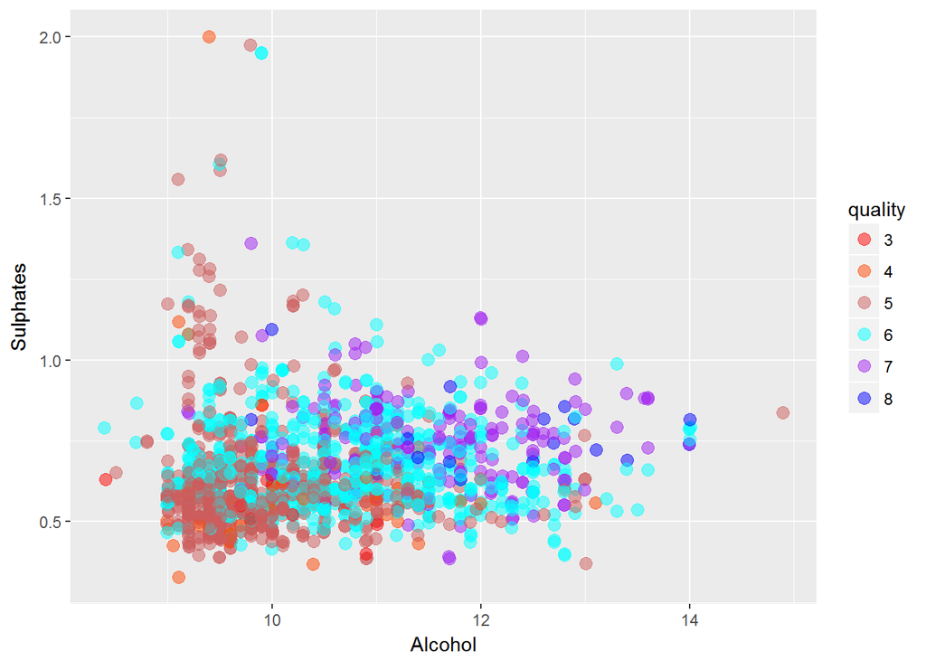

> For sulphates, generally higher quality wines tend to have higher levels of alcohol and sulphates. Let’s put these three variables which had the highest correlation with quality (alcohol, volatile acidity, sulphates) together.

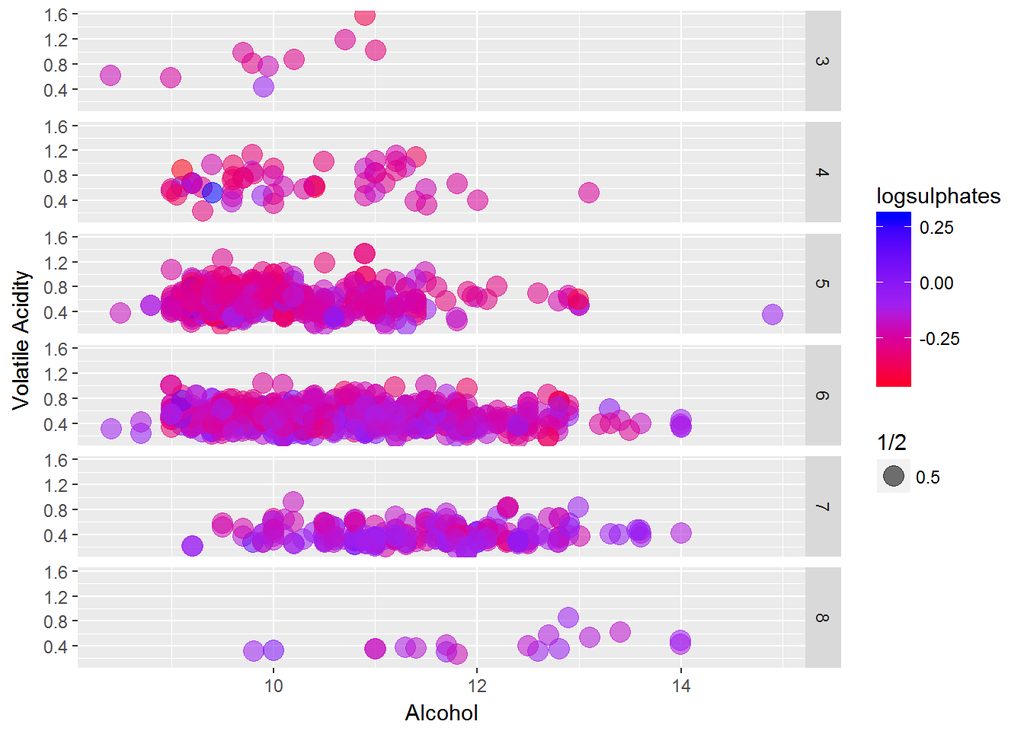

> We’ve changed the color coding for this plot. Now, the log10 of sulphates ranges from red (low sulphates) to blue (high sulphates), and the graph is faceted over quality with volatile acidity on the y-axis and alcohol on the x-axis. As a general rule, higher-quality wines have more alcohol (concentrated right), less volatile acidity (concentrated low), and more sulphates (more blue than red).

> We scaled sulphates by log10 in order to normalize its right tail.

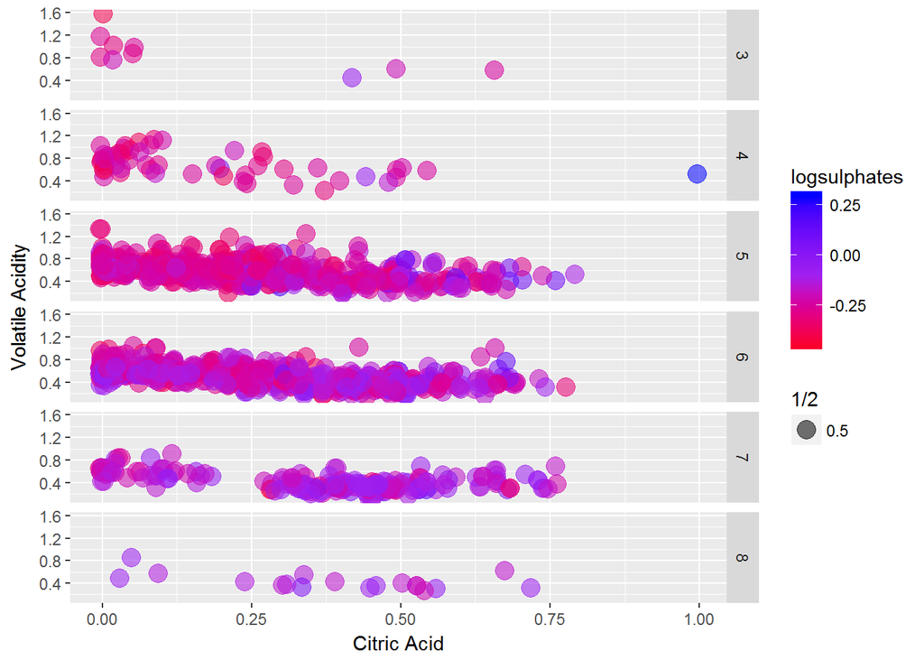

> Finally, we look at citric acid using the same format. This one is not as clear as when alcohol was the x-axis, but again, you can see a general pattern where higher quality wines have more sulphates, less volatile acidity and slightly more right-skew.

```
##
## Calls:
## m1: lm(formula = as.numeric(quality) ~ alcohol, data = red)
## m2: lm(formula = as.numeric(quality) ~ alcohol + sulphates, data = red)
## m3: lm(formula = as.numeric(quality) ~ alcohol + sulphates + volatile.acidity,
##     data = red)
## m4: lm(formula = as.numeric(quality) ~ alcohol + sulphates + volatile.acidity +
##     citric.acid, data = red)
## m5: lm(formula = as.numeric(quality) ~ alcohol + sulphates + volatile.acidity +
##     citric.acid + chlorides, data = red)
## m6: lm(formula = as.numeric(quality) ~ alcohol + sulphates + volatile.acidity +
##     citric.acid + chlorides + total.sulfur.dioxide, data = red)
## m7: lm(formula = as.numeric(quality) ~ alcohol + sulphates + volatile.acidity +
##     citric.acid + chlorides + total.sulfur.dioxide + density,
##     data = red)
##
## ==========================================================================================================================
##                              m1            m2            m3            m4            m5            m6            m7
## --------------------------------------------------------------------------------------------------------------------------
##   (Intercept)              -0.125        -0.625***      0.611**       0.646**       0.769***      0.985***     -2.953
##                            (0.175)       (0.177)       (0.196)       (0.201)       (0.202)       (0.206)      (11.990)
##   alcohol                   0.361***      0.346***      0.309***      0.309***      0.292***      0.276***      0.280***
##                            (0.017)       (0.016)       (0.016)       (0.016)       (0.016)       (0.017)       (0.020)
##   sulphates                               0.994***      0.679***      0.696***      0.871***      0.908***      0.903***
##                                          (0.102)       (0.101)       (0.103)       (0.111)       (0.111)       (0.112)
##   volatile.acidity                                     -1.221***     -1.265***     -1.155***     -1.104***     -1.114***
##                                                        (0.097)       (0.113)       (0.115)       (0.115)       (0.120)
##   citric.acid                                                        -0.079         0.021         0.065         0.044
##                                                                      (0.104)       (0.106)       (0.106)       (0.124)
##   chlorides                                                                        -1.663***     -1.763***     -1.747***
##                                                                                    (0.405)       (0.403)       (0.406)
##   total.sulfur.dioxide                                                                           -0.002***     -0.002***
##                                                                                                  (0.001)       (0.001)
##   density                                                                                                       3.923
##                                                                                                               (11.944)
## --------------------------------------------------------------------------------------------------------------------------
##   R-squared                 0.227         0.270         0.336         0.336         0.343         0.352         0.352
##   adj. R-squared            0.226         0.269         0.335         0.334         0.341         0.349         0.349
##   sigma                     0.710         0.690         0.659         0.659         0.656         0.651         0.652
##   F                       468.267       294.988       268.912       201.777       166.407       143.910       123.298
##   p                         0.000         0.000         0.000         0.000         0.000         0.000         0.000
##   Log-likelihood        -1721.057     -1675.142     -1599.384     -1599.093     -1590.662     -1580.192     -1580.138
##   Deviance                805.870       760.894       692.105       691.852       684.595       675.689       675.643
##   AIC                    3448.114      3358.284      3208.768      3210.186      3195.324      3176.384      3178.276
##   BIC                    3464.245      3379.793      3235.654      3242.448      3232.964      3219.401      3226.670
##   N                      1599          1599          1599          1599          1599          1599          1599
## ==========================================================================================================================
```

> This model is described as: quality = 0.985 + 0.276alcohol + 0.908sulphates - 1.104volatile.acidity + 0.065citric.acid - 1.763chlorides - 0.002total.sulphur.dioxide

# Multivariate Analysis

### Were there any interesting or surprising interactions between features?

> At this point, after so much exploration of the data, most of the interactions uncovered were expected.

### OPTIONAL: Did you create any models with your dataset? Discuss the strengths and limitations of your model.

> I created a multiple linear regression model. At the end of the day, R-squared tops out at around 0.352, so still a fairly low number; but again, I am relatively pleased with the result as we are working with data that has human biases.

# Final Plots and Summary

### Plot One

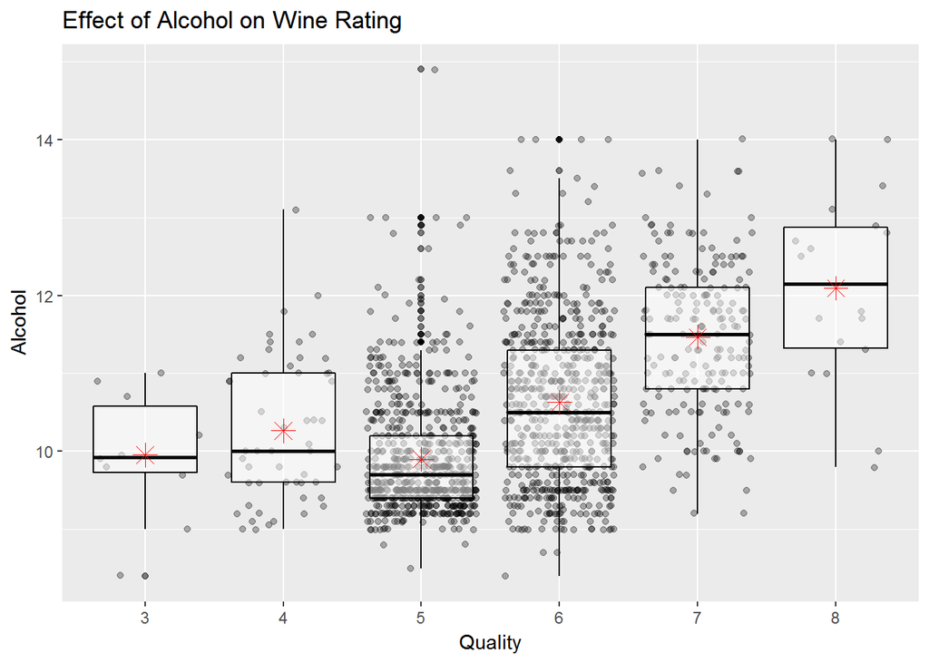

### Description One

> Our strongest relationship and the best predictor of wine rating. The higher the alcohol content of a wine, the better the tasters rated it. Looking at the plot, means and medians tend to coincide for each facet of quality, and thus for a particular “quality grade”, the distribution is fairly normal.

### Plot Two

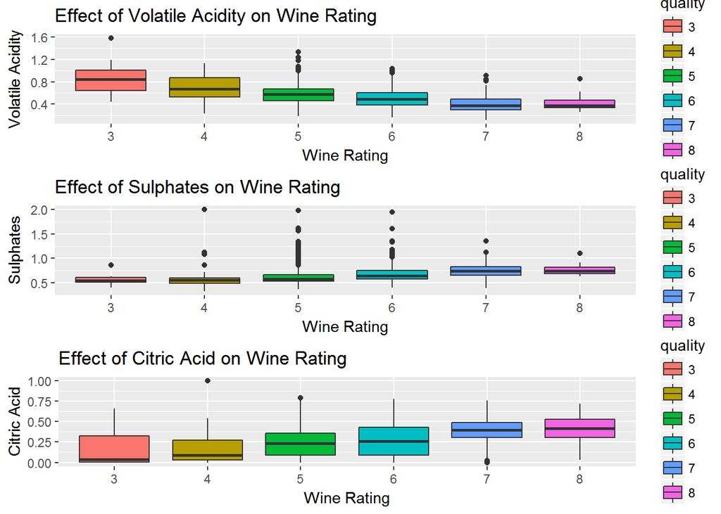

### Description Two

> And the next three strongest predictors. Volatile acidity (acetic acid) has a consistent downward effect on wine rating. Sulphates (antimicrobial and antioxidant additives) have a consistent upward effect on wine rating. Citric acid (affects “freshness” of wine) has a small but noticeably positive effect on rating. These three work with alcohol to produce the best-rated wines.